# Price Prediction for the Hotels Europe Data

John Joyce

2/14/2021

# Overview

The aim of this project is to predict prices for hotels in Europe. It uses the *hotels-europe* data available [here](https://osf.io/r6uqb/). The data has features about the ratings, price, location, promotional offers, and room scarcity of the hotels. This project will focus on predicting price for a single **weekend in April 2018** in the following cities: Berlin, Munich, Vienna, Budapest, Prague, Warsaw. It will only look at hotels which cost less than 500 EUR per night. After filtering to match these criteria, the data has about 1200 observations. The mean nightly price in the sample is 138 EUR.

# Basic Data Prep

These are the basic data preparation steps:

1. load and join *price* and *features* tables on **hotel_id**
2. filter the data to match the desired cities, time period, and property type (only hotels)
3. filter the data to exclude nightly prices above 500 EUR
4. drop NAs - there are only 54

# Exploratory Data Analysis

A quick check on the correlation among the variables show that ratings and the number of reviews are correlated with price:

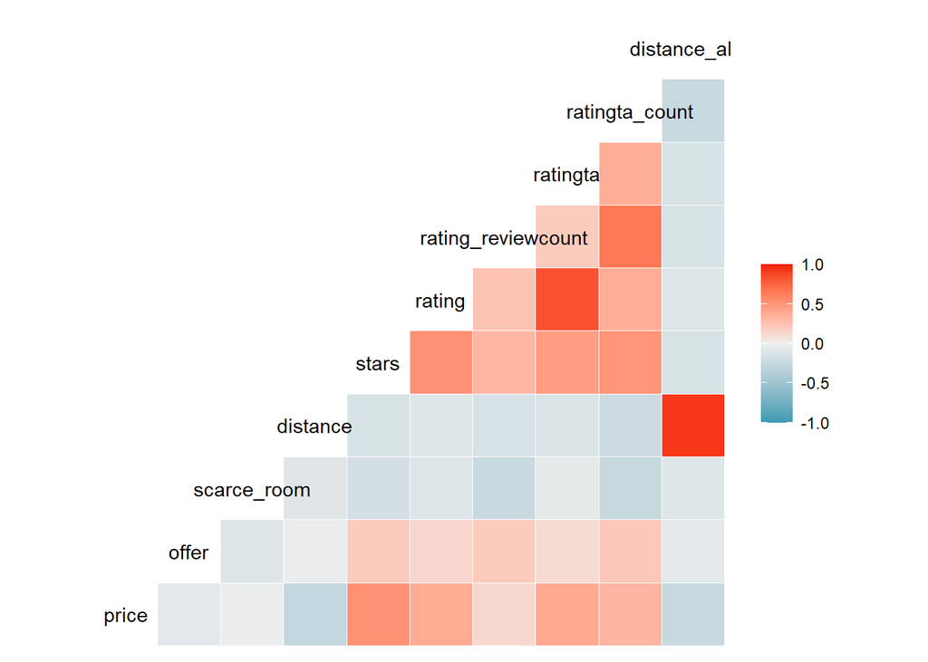

Some of the variables have very skewed distributions, but they can be worked into a normal shape with a log transformation. One example is this **review count** variable. This can help accommodate a linear pattern between the variable and the target (price), which is helpful for linear regression.

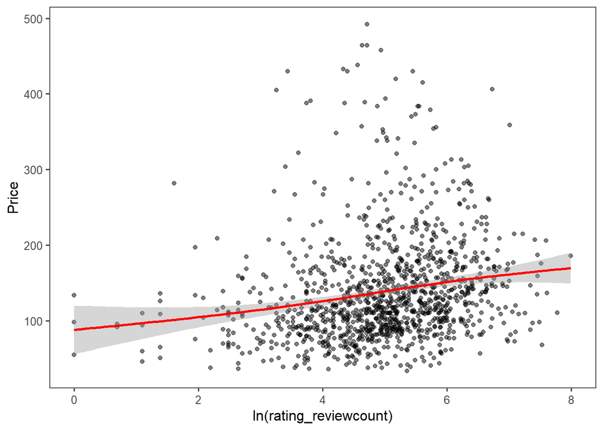

The mean prices vary from city to city, but not as much as one might expect:

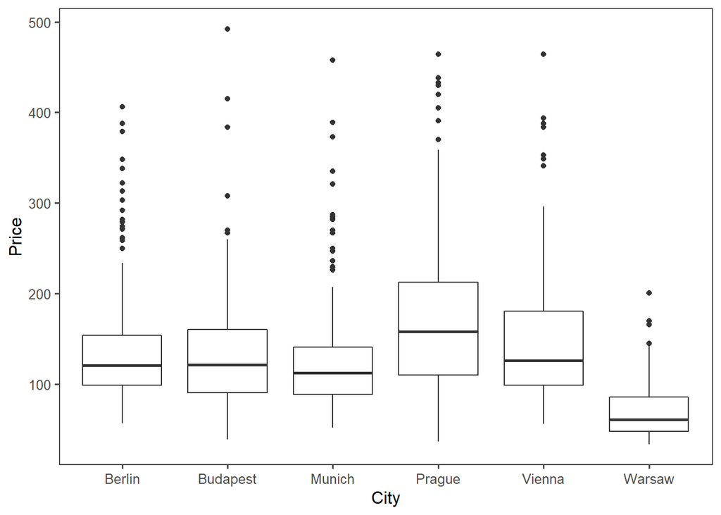

It is apparent that the **stars** rating for a hotel is going to play an important role in predicting price:

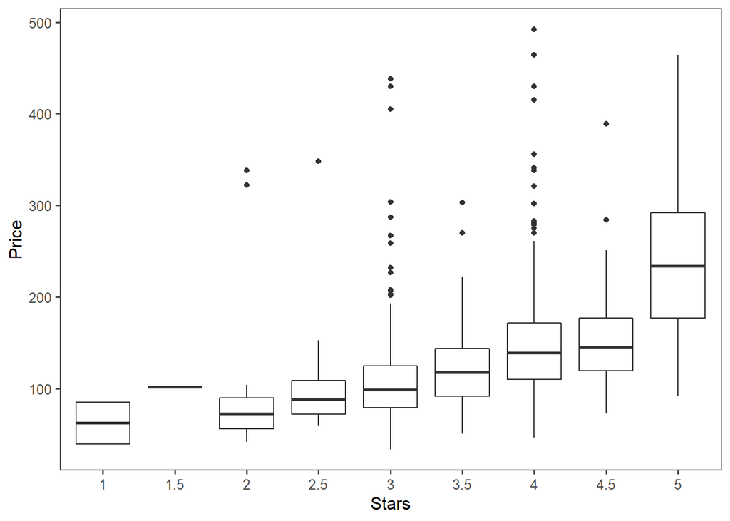

One more thing to consider is whether these hotels are actually located in the cities they are grouped with. For example, some hotels in the Berlin market are actually located in nearby Schoenefeld, not in the city of Berlin itself. With one notable exception, it seems that hotels located in neighbouring cities (“1” on this graph) are cheaper on average.

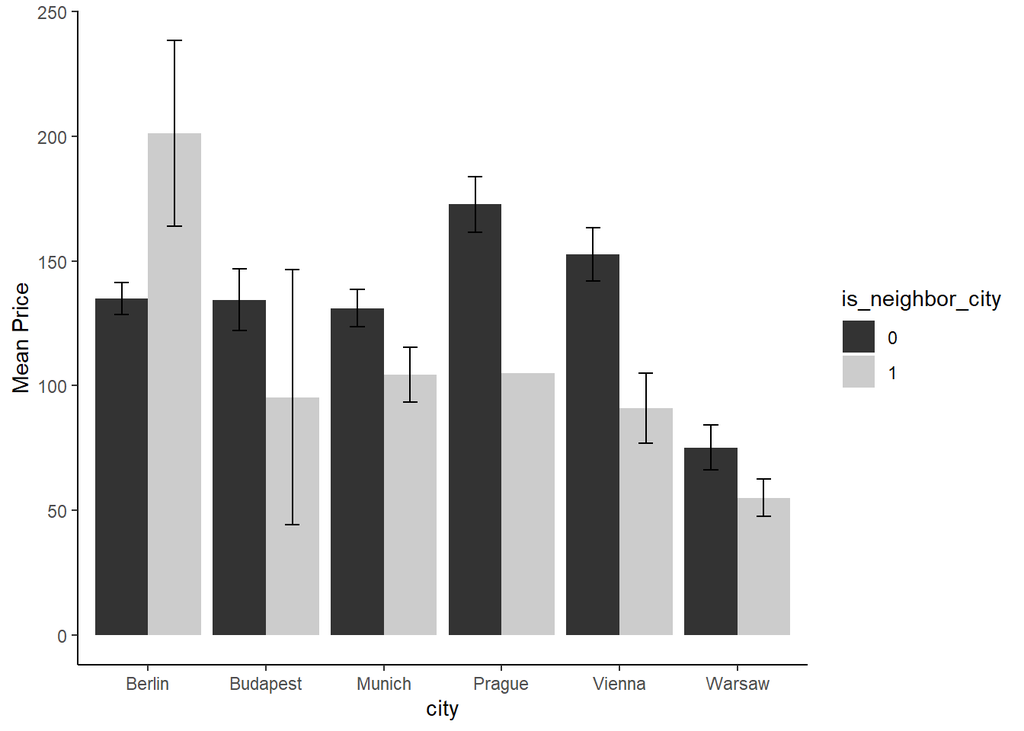

# Functional Form / Feature Engineering

Log transformations are taken for the following variables for use in the linear regression models:  
* distance  
* distance_alter  
* ratings_reviewcount  
* ratingta_count

One new feature is engineered: a binary variable which indicates whether a hotel is **actually in a neighbouring city** instead of the city given as its market.

# Prediction

The data is split into training and test sets, with 80% of the data available for training and 20% reserved for evaluation.

Three different model methods are used:  
* OLS linear regression  
* rpart decision tree  
* random forest

Every model is fit on three sets of predictors, with increasing complexity:  
* **basic**: city, stars, rating, distance from the city center, review count (non-Tripadvisor)  
* **mid**: everything in basic + holidays, promotional offers, if it’s a neighbouring city, and a variable interaction for OLS  
* **all**: everything in mid + any other potentially useful variable remaining (precise neighbourhood, room scarcity, another series of ratings and reviews from Tripadvisor)

The OLS models use slightly different predictors than the tree models. OLS models use some log-transformed variables, as well as an interaction term for **city** and **is_neighbour_city** in the **mid** and **all** formulas. The tree models use untransformed variables and do not receive the interaction term, because they can uncover non-linear patterns and find interactions independently. Except for these differences, the **basic**, **mid**, and **all** formulas for OLS and tree models are the same.

Tuning parameters for rpart and random forest are chosen via five-fold cross-validation.

# Model Evaluation

## Performance in Cross-validation

The table below shows the mean RMSE across all five folds in cross-validation during model training. Surprisingly, the differences between the different models are fairly small. The performance of the rpart models is suspiciously homogeneous. However, manually tinkering with the tuning parameters only increased the variation among these models by making some of them worse.

The OLS models benefited from increasing complexity, but the most complex random forest suffered from the worst RMSE out of all nine models. One possible explanation: including review and rating information from multiple sources (only available in the **all** model) may have been a mistake: these features are highly correlated with one another, and this may have led to excessively correlated trees in the random forest.

**The selected model is random forest model 2**, because it has the lowest RMSE in cross-validation.

| Model | Variables | Mean_RMSE |
| --- | --- | --- |
| OLS 1 | basic | 54.6 |
| OLS 2 | mid | 54.5 |
| OLS 3 | all | 52.5 |
| Rpart 1 | basic | 55.8 |
| Rpart 2 | mid | 55.9 |
| Rpart 3 | all | 55.9 |
| Random forest 1 | basic | 52.0 |
| Random forest 2 | mid | 51.2 |
| Random forest 3 | all | 58.2 |

## Performance on the Test Set

The best model performs even better on the test set. The **RMSE is 48.1** (vs 51.2 in cross-validation) and the **mean absolute error** is 32.6.

## Residuals and Diagnostics

The model has some weaknesses. It does not perform equally well in all of the cities in the sample. In fact, it performs particularly poorly in Budapest.

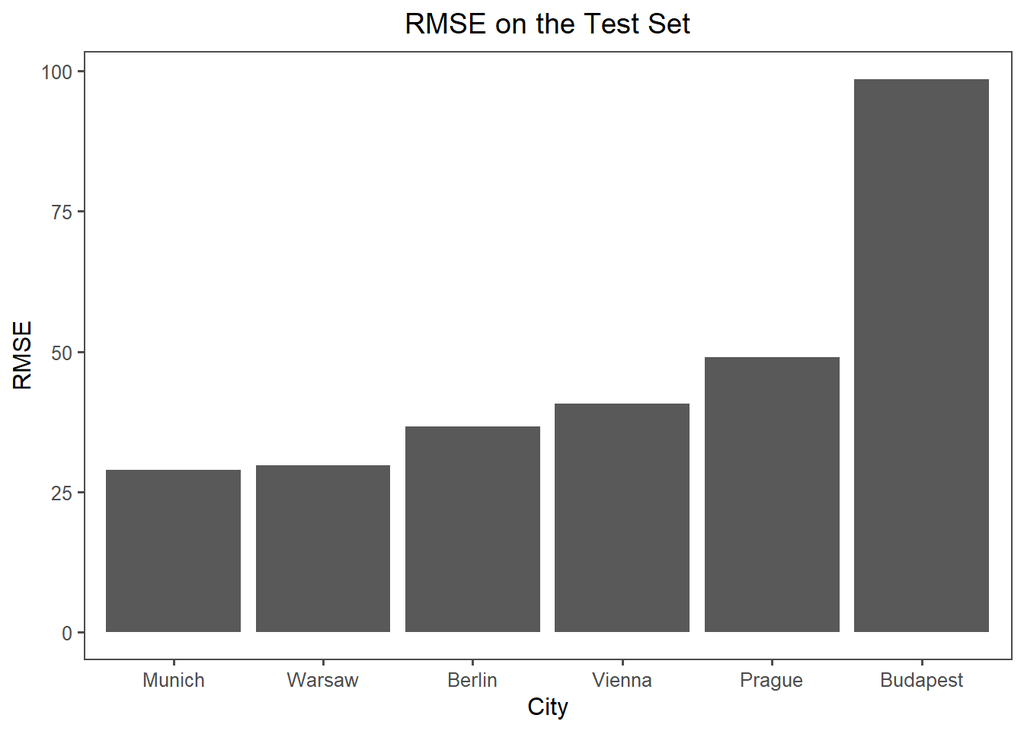

Below are the top ten *negative* prediction errors, where the model predicted a price which is too low. There is no general pattern visible here, except that the prices are all significantly above the mean of 138 EUR. The top two errors are in Budapest, contributing to the poor RMSE for that group.

| hotel_id | city | distance | stars | rating | rating_reviewcount | price | prediction | error |
| --- | --- | --- | --- | --- | --- | --- | --- | --- |
| 3310 | Budapest | 1.1 | 4.0 | 4.0 | 112 | 492 | 119 | -373.3 |
| 3367 | Budapest | 1.6 | 4.0 | 4.5 | 273 | 415 | 149 | -266.4 |
| 2174 | Berlin | 0.3 | 5.0 | 4.8 | 308 | 379 | 267 | -112.4 |
| 11354 | Munich | 0.9 | 4.0 | 4.5 | 165 | 270 | 166 | -104.2 |
| 21901 | Vienna | 1.4 | 4.0 | 3.7 | 53 | 231 | 143 | -87.9 |
| 14800 | Prague | 2.3 | 4.5 | 4.0 | 197 | 224 | 152 | -71.9 |
| 2020 | Berlin | 7.4 | 3.0 | 3.2 | 64 | 171 | 102 | -69.0 |
| 21925 | Vienna | 3.9 | 3.0 | 2.7 | 193 | 182 | 116 | -66.5 |
| 1923 | Berlin | 3.5 | 4.0 | 4.4 | 108 | 185 | 119 | -66.4 |
| 22095 | Vienna | 0.3 | 4.0 | 4.1 | 313 | 255 | 189 | -66.1 |

Below are the top ten *positive* prediction errors, where the model predicted a price which is too high. The pattern here is perfectly clear: the model is struggling with hotels in Prague.

| hotel_id | city | distance | stars | rating | rating_reviewcount | price | prediction | error |
| --- | --- | --- | --- | --- | --- | --- | --- | --- |
| 14419 | Prague | 1.7 | 3.0 | 3.7 | 44 | 37 | 137 | 100.4 |
| 14511 | Prague | 0.9 | 5.0 | 4.6 | 58 | 202 | 302 | 100.1 |
| 14946 | Prague | 0.1 | 3.5 | 4.0 | 134 | 99 | 194 | 95.3 |
| 14405 | Prague | 2.4 | 3.0 | 4.0 | 24 | 64 | 152 | 88.3 |
| 14847 | Prague | 1.4 | 5.0 | 4.6 | 118 | 161 | 249 | 88.3 |
| 22105 | Vienna | 0.5 | 5.0 | 4.1 | 538 | 134 | 221 | 86.7 |
| 14730 | Prague | 4.9 | 3.0 | 3.7 | 35 | 38 | 124 | 85.6 |
| 14409 | Prague | 2.5 | 3.0 | 3.9 | 58 | 66 | 147 | 80.8 |
| 14713 | Prague | 2.8 | 3.0 | 3.7 | 19 | 77 | 155 | 78.0 |
| 3146 | Budapest | 3.1 | 5.0 | 3.9 | 365 | 92 | 169 | 77.2 |

The variable importance plot shows that **stars** is the most important variable by a considerable margin.

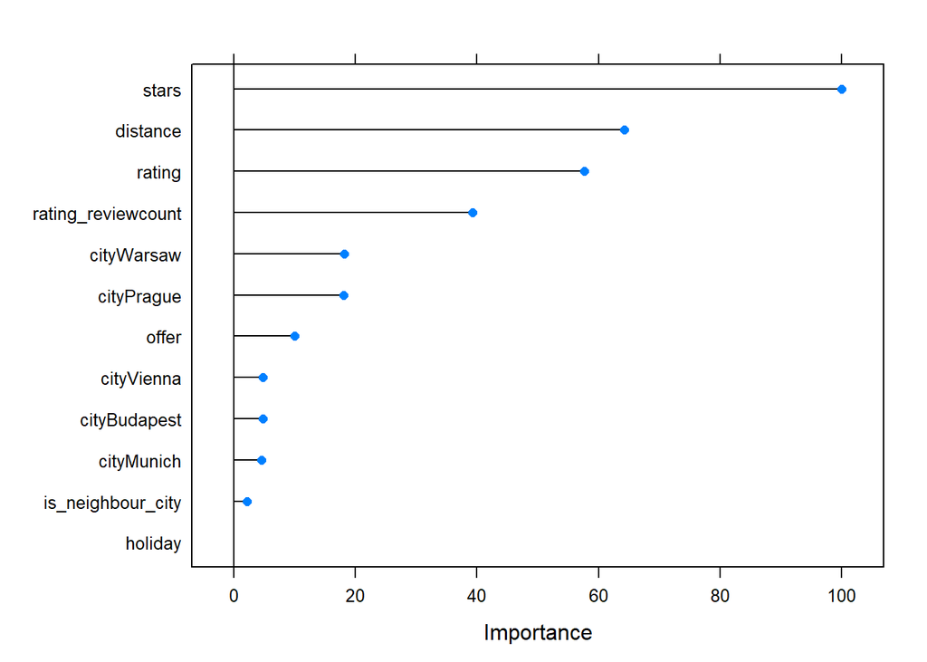

The partial dependence plot for the **stars** variable in the model shows that the expected value for price is quite higher when the number of stars is high.

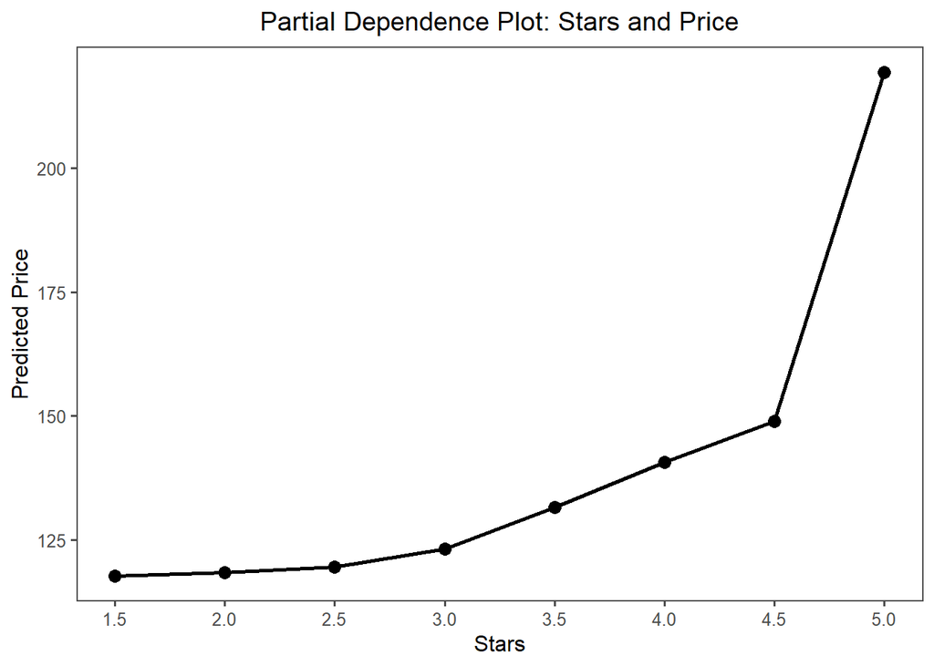

# Conclusion

The best model achieves an **RMSE of 51.2 in cross-validation** and **48.1 on the test set**. This is a stable and decent performance. With an **MAE of 32.6 on the test set**, one can expect to predict hotel prices on this population with an average error of 32.6 EUR, using only basic and public information. The biggest weakness of this model is its poor performance in Budapest and Prague. If predictions in these two cities could be improved, the model would have considerably better performance metrics overall.

Thinking external validity: this particular iteration of the model would likely not be useful today due to the different circumstances in hotel pricing due to COVID. However, it might be worth re-fitting with the same formula in a post-pandemic world.